# Initial population sizes

# 1 Preamble

This is an Electronic Supplement to the manuscript Marques et al. “Quantifying Deepwater Horizon oil spill induced injury on pelagic cetaceans” submitted to Marine Ecology Progress Series (MEPS).

There are 8 Electronic Supplements to the paper. The master file containing links to all the other 7 additional Electronic Supplements related to this paper is ES0_ElectronicSupplements.

You might be reading this file as a pdf or as an html. The links on this file only work if you are using the html version of it, available via the github repository or if you compiled it yourself as html and you have all the 8 html files in the same folder. Otherwise, as a pdf distributed as an Electronic Supplement to the MEPS paper, the links might not work. *They might work. If it is possible, we can work with the MEPS Editorial Office such that we can add links below that will link to actual files, say the pdfs of each of these 8 files, on the publisher server*.

## 1.1 Version history

This section details the version history for static pdf files submitted as Electronic Supplement pdfs:

- 1.0 [12 Aug 2022] Version included as a pdf Electronic Supplement in the MEPS original submission
- 2.0 [10 Feb 2023] Version included as a pdf Electronic Supplement in the MEPS re-submission after 1st round of reviewer’s comments

# 2 Introduction

In this document we present the distribution for the initial population sizes, population exposed and proportion exposed for each of the stocks considered in the pelagic paper.

These population sizes were obtained from the models of

Roberts, J. J.; Best, B. D.; Mannocci, L.; Fujioka, E.; Halpin, P. N.; Palka, D. L.; Garrison, L. P.; Mullin, K. D.; Cole, T. V. N.; Khan, C. B.; McLellan, W. A.; Pabst, D. A. & Lockhart, G. G. 2016 Habitat-based cetacean density models for the U.S. Atlantic and Gulf of Mexico *Scientific Reports* **6**: 22615 DOI: [10.1038/srep22615](https://www.nature.com/articles/srep22615)

To obtain the number of animals exposed to oil (and hence the proportion of the population exposed to oil) the estimated fraction of the population based on the density surfaces that was contained in the area considered to be affected by oil was quantified. This area is shown in the image below

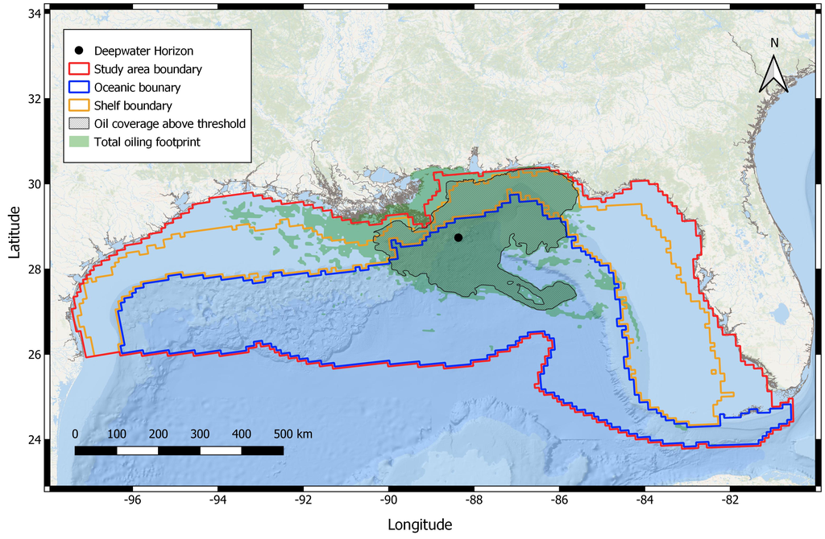

The taxonomic units considered and the corresponding codes are:

- Bwsp - beaked whales, Beaked whales sppp
- Fatt - pygmy killer whale, *Feresa attenuata*
- Ggri - Risso’s dolphin, *Grampus griseus*
- Gmac - short-finned pilot whale, *Globicephala macrorhynchus*
- Kosp - Kogia whales, *Kogia* spp.
- Pele - melon-headed whale, *Peponocephala electra*
- Pmac - sperm whale, *Physeter macrocephalus*
- Satt - pantropical spotted dolphin, *Stenella attenuata*
- Sbre - rough-toothed dolphin, *Steno bredanensis*
- Scly - Clymene dolphin, *Stenella clymene*
- Scoe - striped dolphin, *Stenella coeruleoalba*
- Sfro - Atlantic spotted dolphin, *Stenella frontalis*
- Slon - spinner dolphin, *Stenella longirostris*
- Ttro - offshore bottlenose dolphins, *Tursiops truncatus*
- Ttrs - shelf bottlenose dolphins, *Tursiops truncatus*

# 3 Population size and proportion exposed

For each taxonomic unit, we present estimated total population size, the estimated population size within the area covered (above threshold) by oil, and also show maps of density to demonstrate how the above values were derived.

For each taxonomic unit, both of these files are provided in the corresponding folder at the above github repository. All taxonomic units files are inside the corresponding folder inside the folder `InOutBySp`.

To present a spatial perspective of the abundances we require 2 shapefiles (provided in the folder `InputFiles` at the above github repository) common to all pelagic taxonomic units:

- `OilCoverage.shp` - the oil coverage above a threshold
- `Study_Area_GOM_10km_Polygon` - the study area in 10 km grid cells

and two files per pelagic taxonomic unit:

- `N_bycell.csv` - the point estimate of the number of animals per grid cell, where grid cells are defined in `Study_Area_GOM_10km_Polygon`;
- `Prediction_Area.img` - the prediction area for each species

As above, these taxonomic unit specific files are in the folder `InOutBySp`, stored under a sub-folder corresponding to each taxonomic unit.

We can plot these abundance distributions and density estimates over species in turn for each taxonomic unit.

```
## [1] "The following plots are for Bwsp"
## [1] "The spatial density for Bwsp"
```

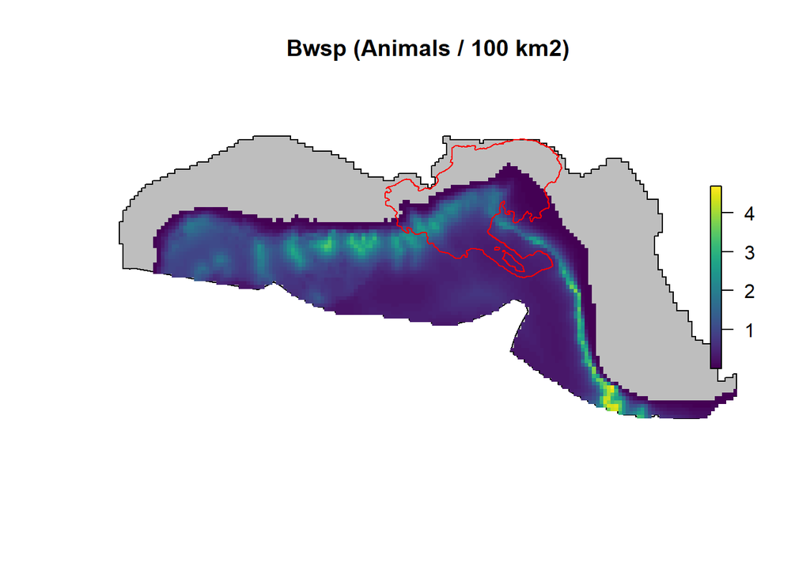

```
## [1] "The number of exposed animals against the number of animals in the initial population"
```

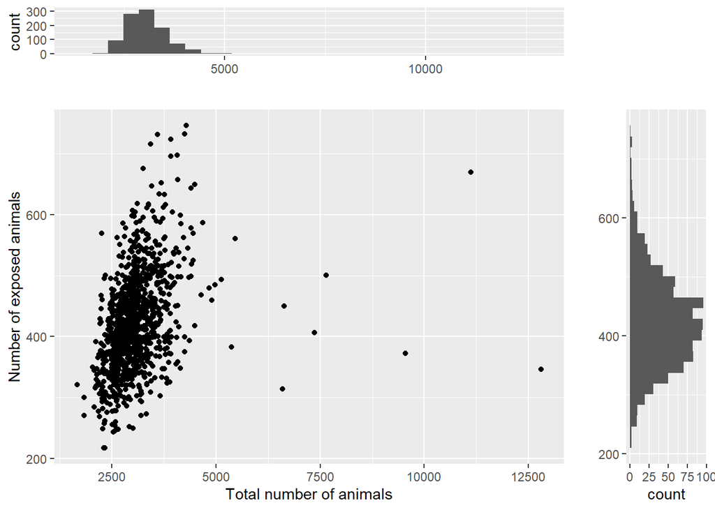

```
## [1] "The proportion of exposed animals against the number of animals in the initial population"
```

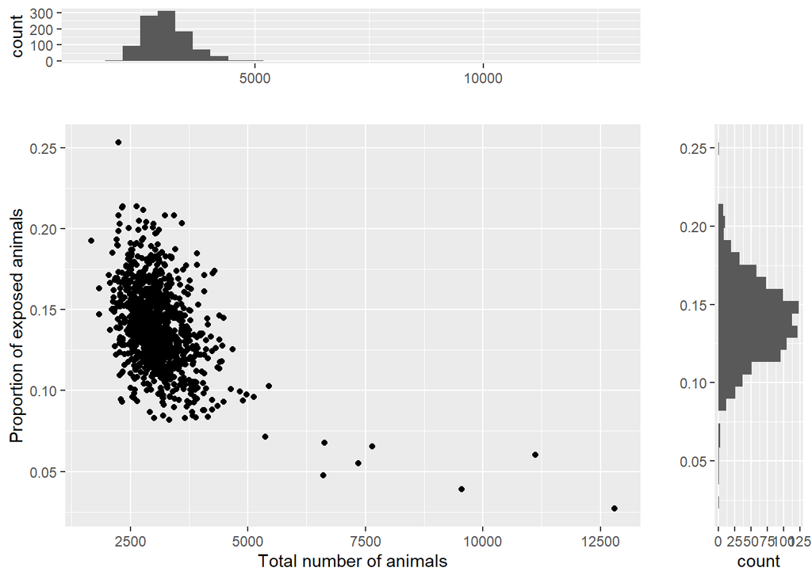

```
## [1] "The following plots are for Fatt"
## [1] "The spatial density for Fatt"
```

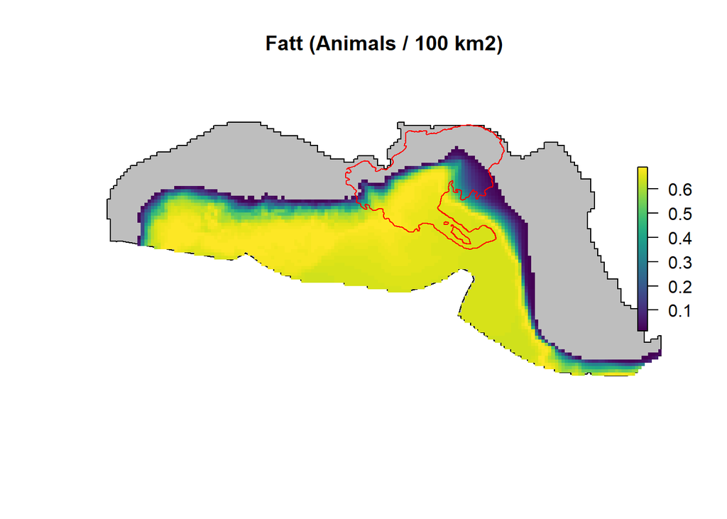

```
## [1] "The number of exposed animals against the number of animals in the initial population"
```

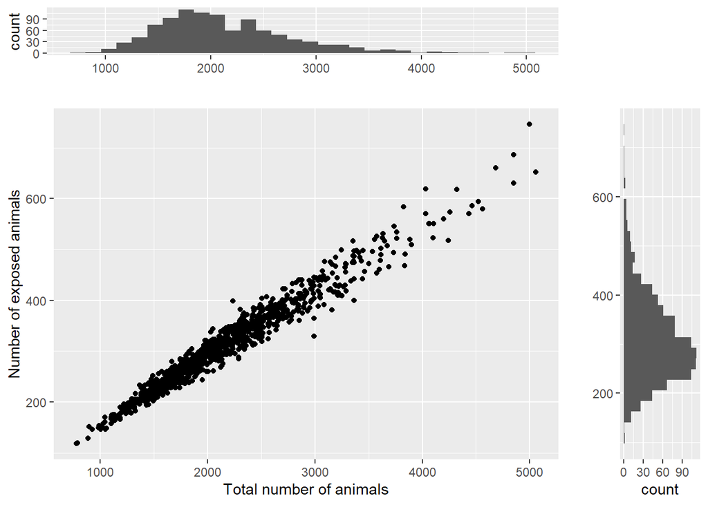

```
## [1] "The proportion of exposed animals against the number of animals in the initial population"
```

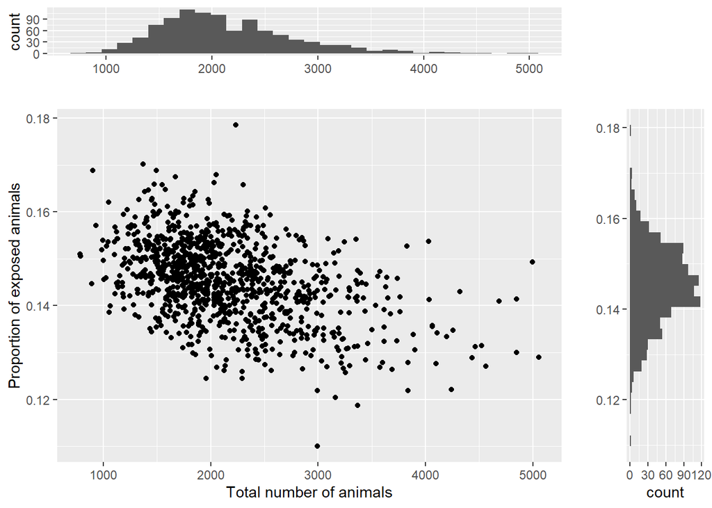

```
## [1] "The following plots are for Gmac"
## [1] "The spatial density for Gmac"
```

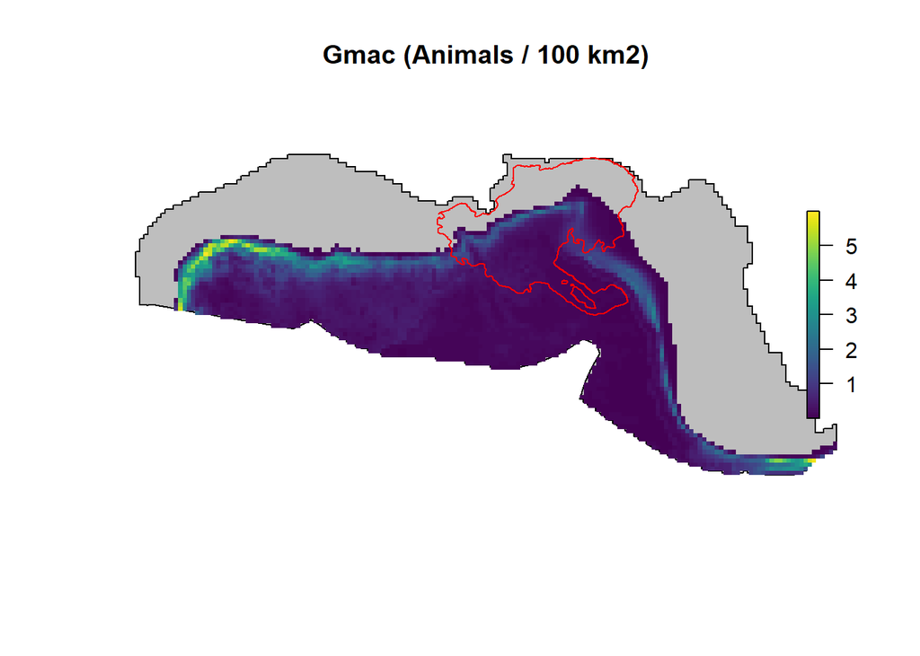

```
## [1] "The number of exposed animals against the number of animals in the initial population"
```

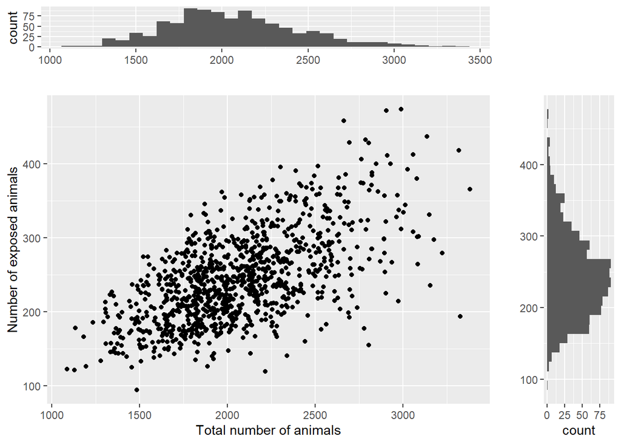

```
## [1] "The proportion of exposed animals against the number of animals in the initial population"
```

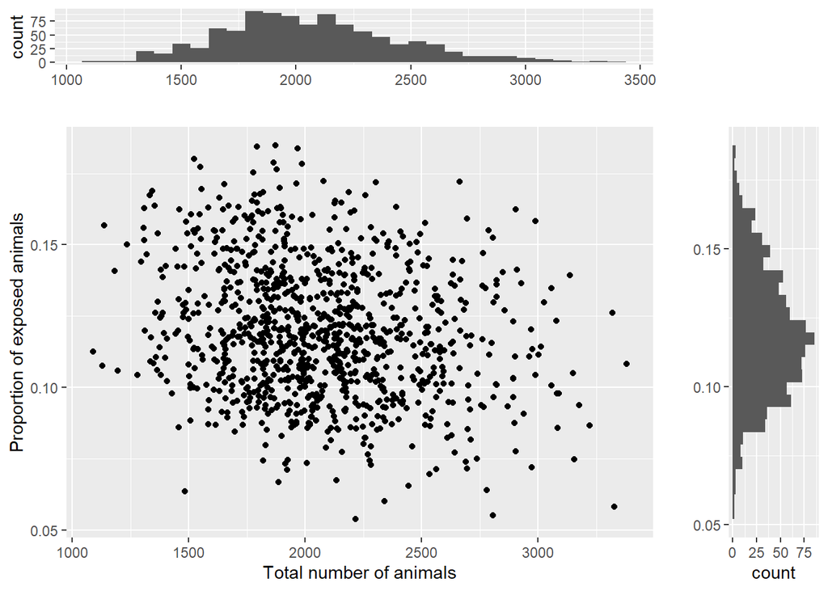

```
## [1] "The following plots are for Ggri"
## [1] "The spatial density for Ggri"
```

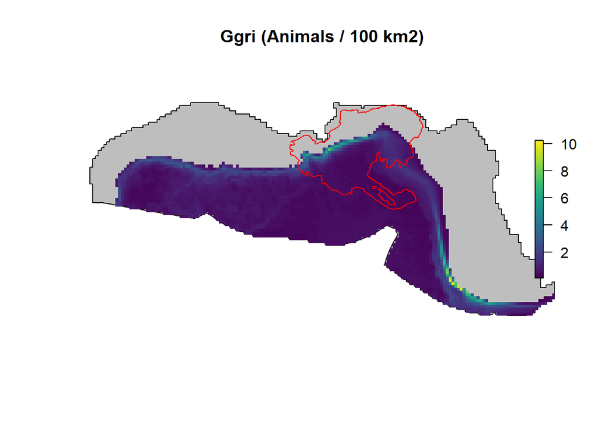

```
## [1] "The number of exposed animals against the number of animals in the initial population"
```

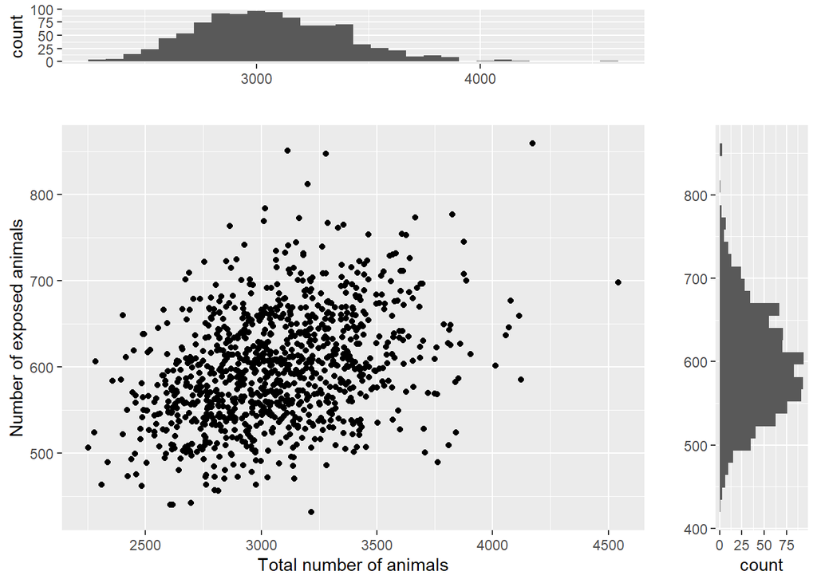

```
## [1] "The proportion of exposed animals against the number of animals in the initial population"
```

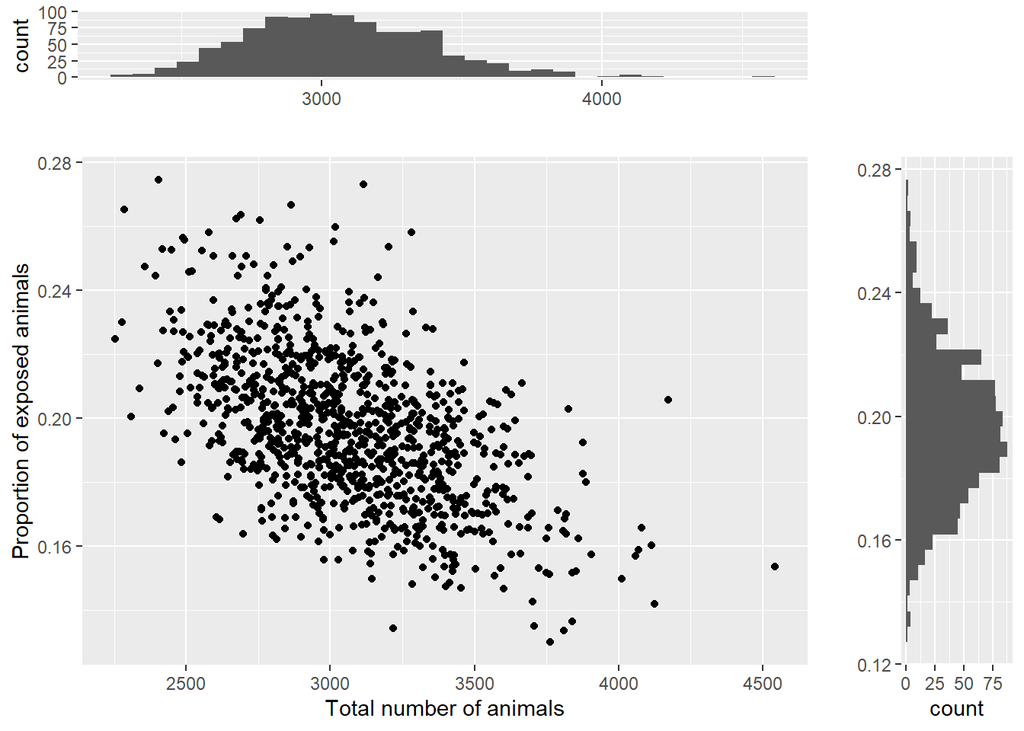

```
## [1] "The following plots are for Kosp"
## [1] "The spatial density for Kosp"
```

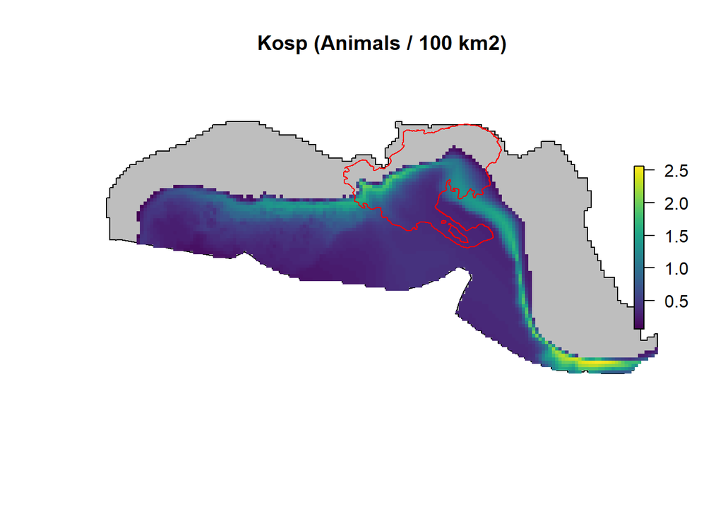

```
## [1] "The number of exposed animals against the number of animals in the initial population"
```

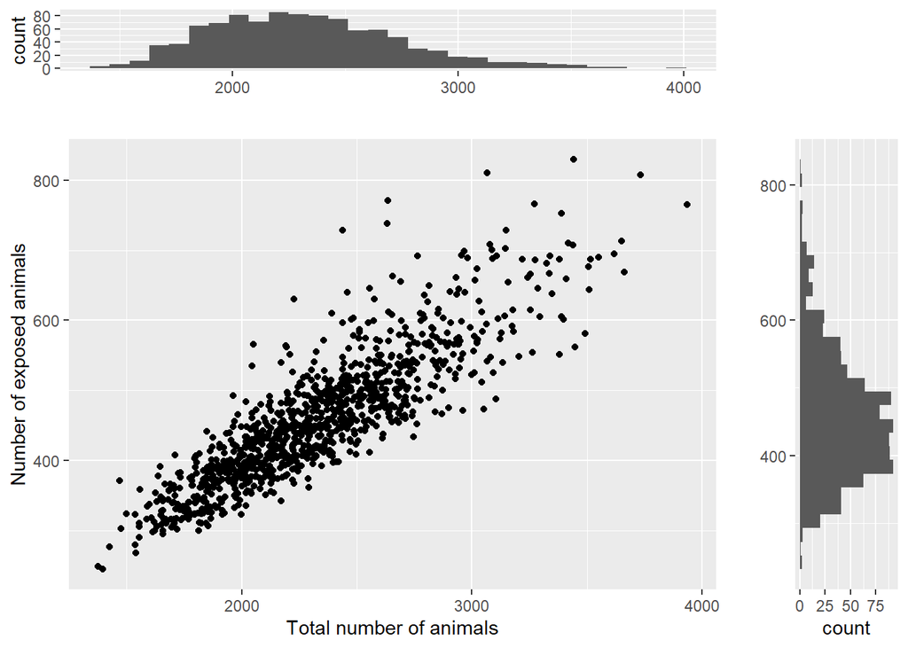

```
## [1] "The proportion of exposed animals against the number of animals in the initial population"
```

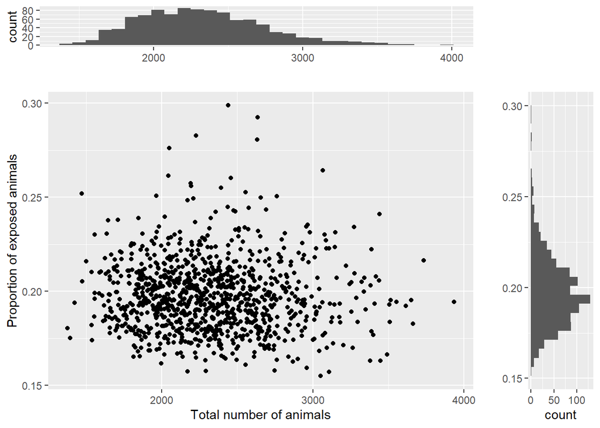

```
## [1] "The following plots are for Pele"
## [1] "The spatial density for Pele"
```

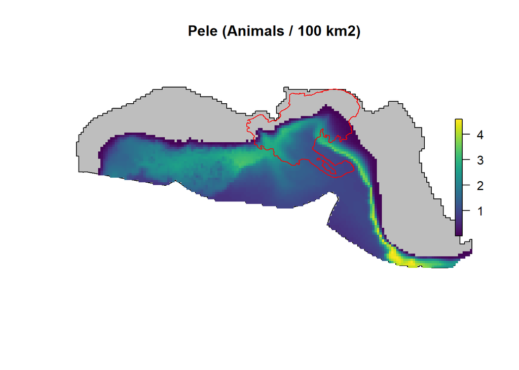

```
## [1] "The number of exposed animals against the number of animals in the initial population"
```

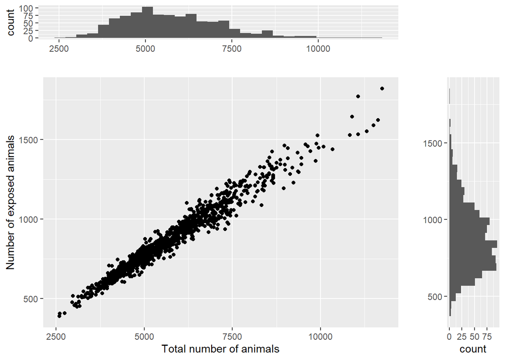

```
## [1] "The proportion of exposed animals against the number of animals in the initial population"
```

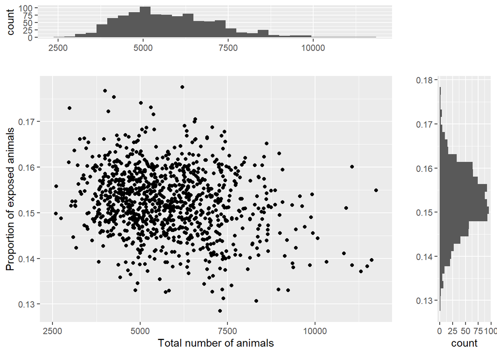

```
## [1] "The following plots are for Pmac"
## [1] "The spatial density for Pmac"
```

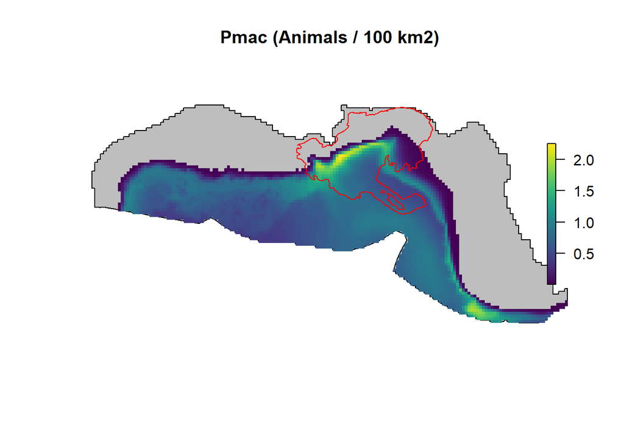

```
## [1] "The number of exposed animals against the number of animals in the initial population"
```

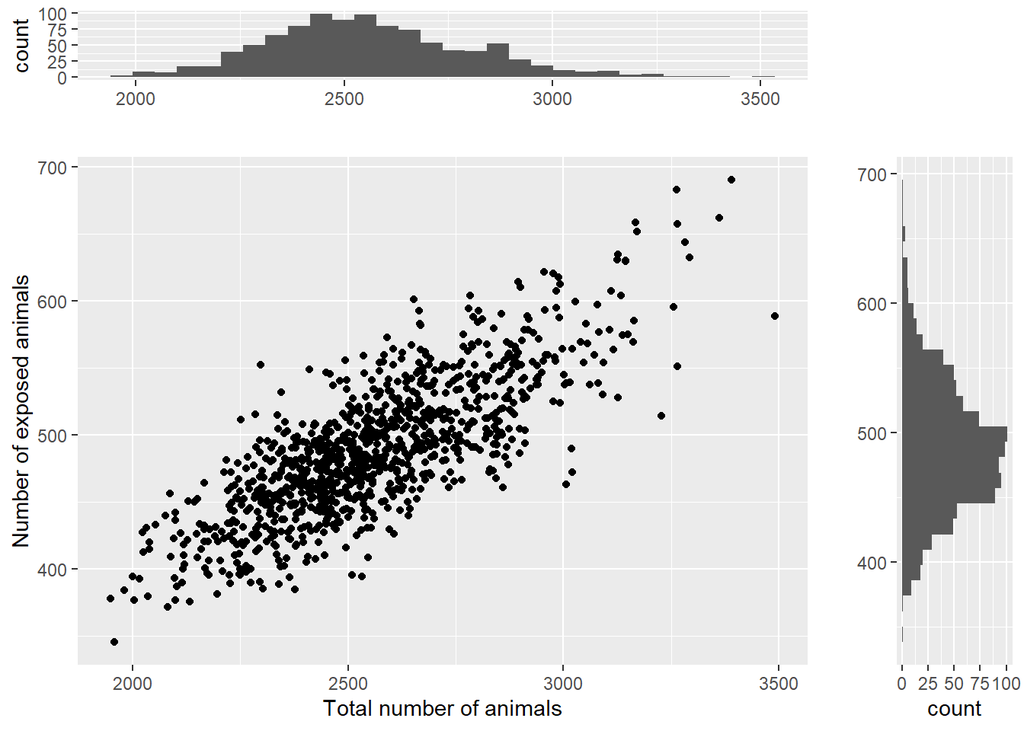

```
## [1] "The proportion of exposed animals against the number of animals in the initial population"
```

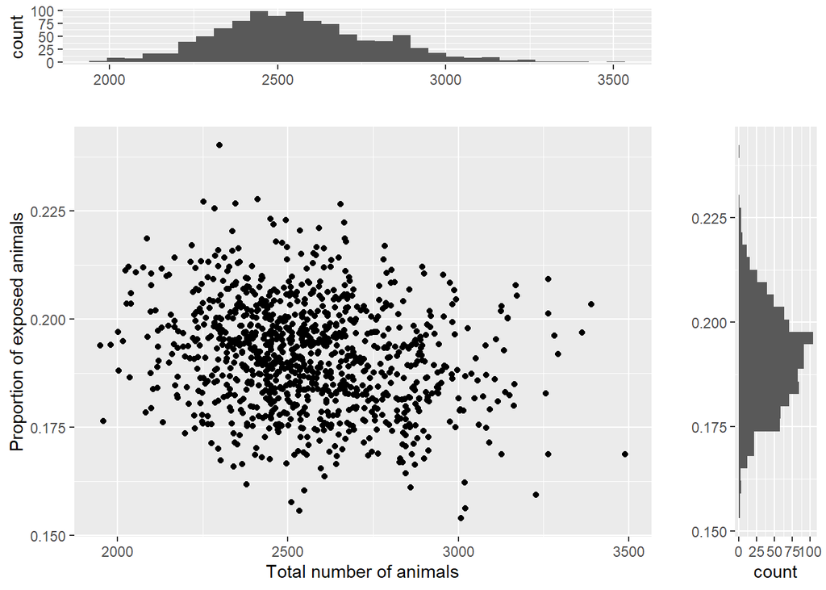

```
## [1] "The following plots are for Satt"
## [1] "The spatial density for Satt"
```

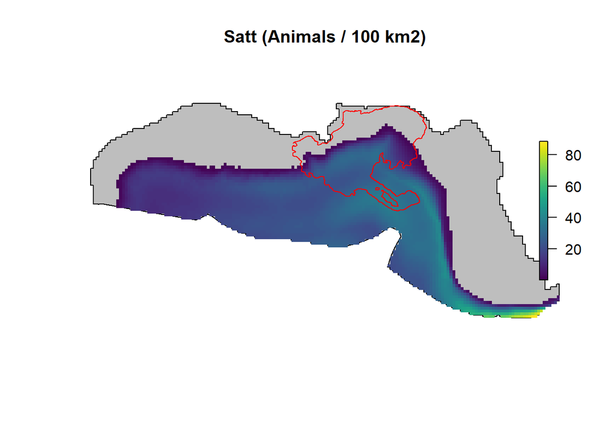

```
## [1] "The number of exposed animals against the number of animals in the initial population"
```

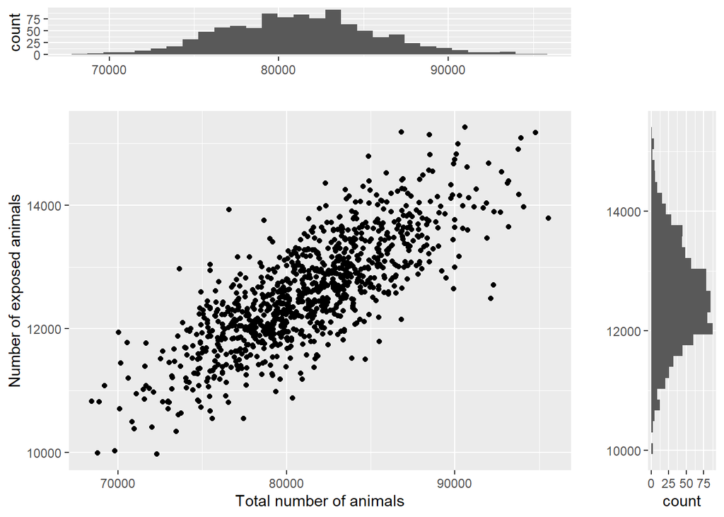

```
## [1] "The proportion of exposed animals against the number of animals in the initial population"
```

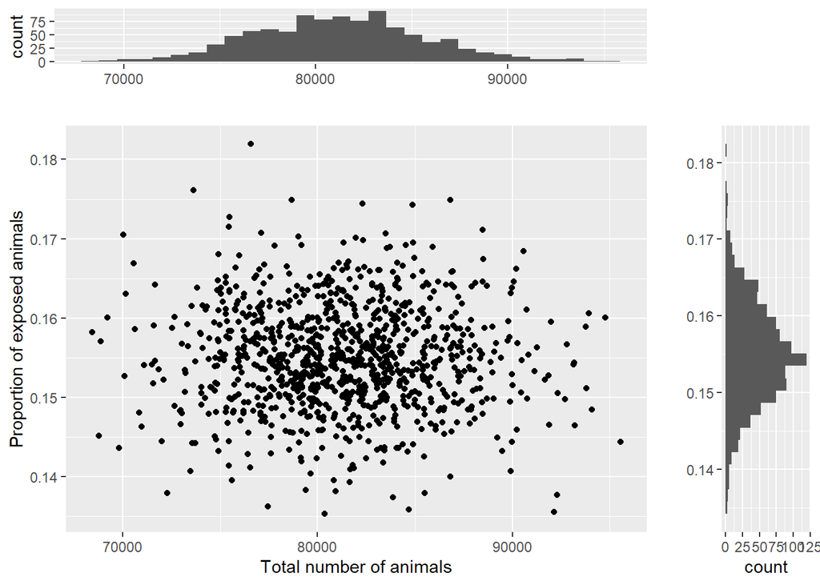

```
## [1] "The following plots are for Sbre"
## [1] "The spatial density for Sbre"
```

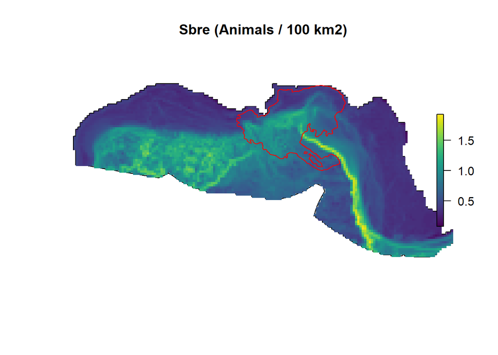

```
## [1] "The number of exposed animals against the number of animals in the initial population"
```

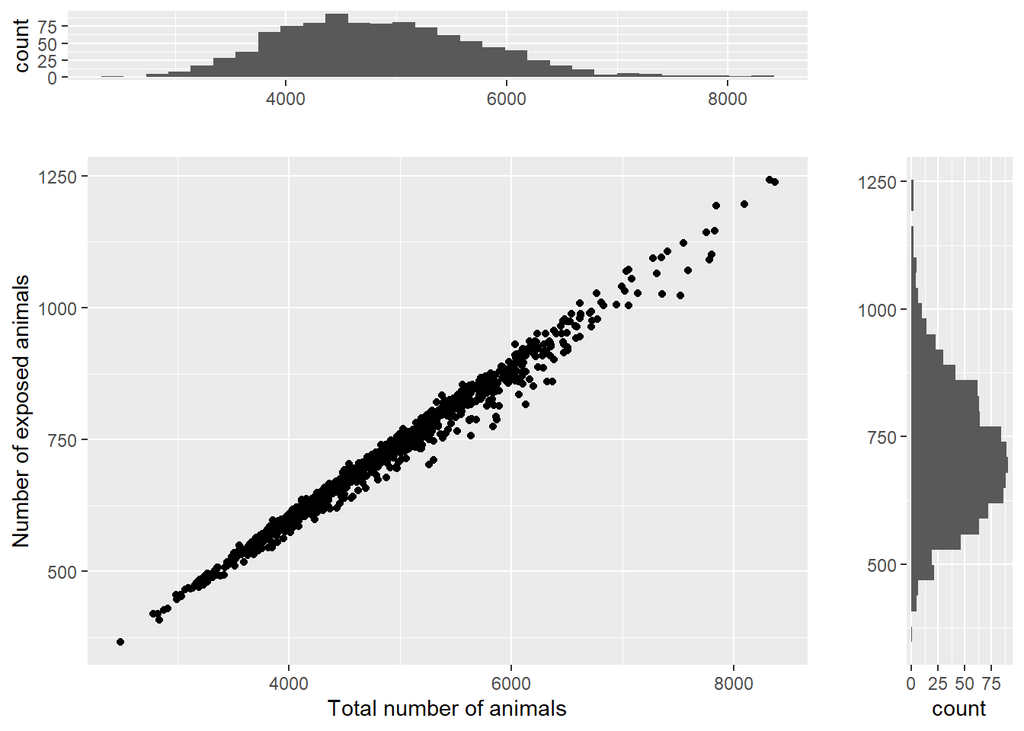

```
## [1] "The proportion of exposed animals against the number of animals in the initial population"
```

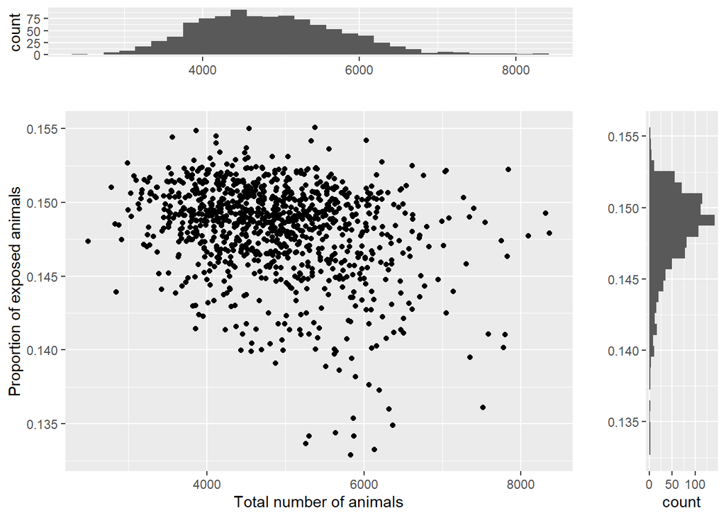

```
## [1] "The following plots are for Scly"
## [1] "The spatial density for Scly"
```

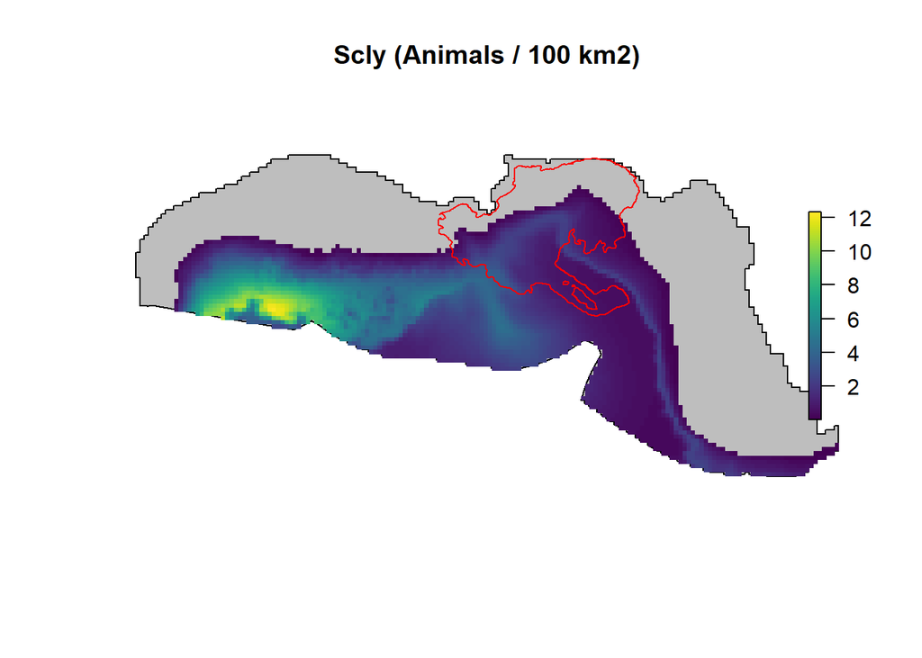

```
## [1] "The number of exposed animals against the number of animals in the initial population"
```

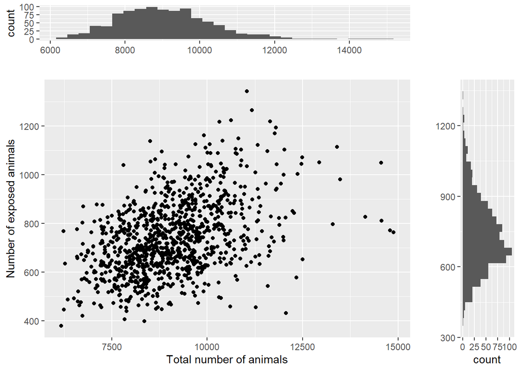